# Random walks and AR(p) models

## Learning outcomes

- Understand some of the simpler time series models.
- Understand random walk processes
- Understand AR(p) processes
- Learn how to fit some appropriate models

## Here's a time series

That's a big trend, right?

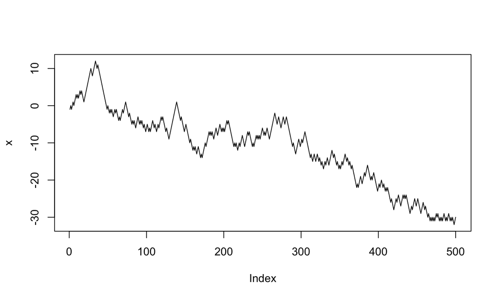

well, …

## Here's how we generate the data

```r
set.seed(123)
y <- cumsum(sample(c(-1, 1), size=1000, replace=TRUE))
```

And what happens when we continue the series…

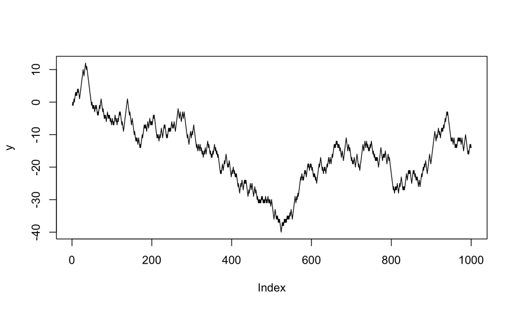

## Generating a one-dimensional random walk

1. Start at zero
2. Flip a coin and move (+1) for heads (-1) for tails
3. Repeat

Where do you end up? - Expected mean is 0 as number of steps gets large \[ \hat{Y}_{t} = Y_{t-1} \]

- The variance gets larger with number of steps
- But in an infinite series, every point (including zero) is crossed an infinite number of times. This causes the **gambler's ruin**.

## A random walk in two dimensions

[figure not shown]

## A random walk in two dimensions

[figure not shown]

## A random walk in two dimensions

[figure not shown]

As the step size decreases, this process approaches **Brownian motion**

## Random walk applications

The steps don't have to be the same size.

- A step size with a Gaussian distribution is useful for modelling stock markets.
- If the step size probability distribution is heavy tailed, you have **Levy flight**.

## Levy flight vs Brownian motion

[figure not shown]

There is evidence that animals such as sharks follow a levy flight pattern (left) when foraging for food - they had previously been thought to approximate Brownian motion (right)

## Random walks in climate

Annoyed with skeptics claiming solar cycles drive climate change, [Turner (2016)](http://www.nature.com/articles/srep23961) put random walks through a spectral filter, and got solar cycles.

[figure not shown]

## But, how do we know that climate change is not a random walk?

- A forced temperature change can show long term persistence. Of course!
- A statistical model is just that, a convenient model of the process, not the process itself.
- We need to integrate our knowledge of the system from elsewhere. We have physics!

## Autoregressive models

## Autoregressive (AR) models

- Output depends **linearly** on its previous values **and** a stochastic term.
- An AR(p) process can be modelled \[Y_{t} = \alpha + \sum_{i=1}^{p} \phi_{i} Y_{t-i} + \epsilon_{t}\]

Where \(\alpha\) is a constant, \(\phi_{i}\) are the model parameters and \(\epsilon_{t}\) is white noise.

For example, an AR(1) process can be written \[Y_{t} = \alpha + \phi Y_{t-1} + \epsilon_{t}\]

And an AR(2) \[Y_{t} = \alpha + \phi_{1} Y_{t-1} + \phi_2 Y_{t-2} + \epsilon_{t}\]

## Simulating from an AR(1) process

```r
# Some R code to simulate data from an AR1 model
set.seed(123)
T = 100
t_seq = 1:T
sigma = 1
alpha = 1
phi = 0.6
y = rep(NA,T)
y[1] = rnorm(1,0,sigma)
for(t in 2:T) y[t] = rnorm(1,alpha + phi * y[t-1], sigma)
```

## Increasing \(\phi\) parameter

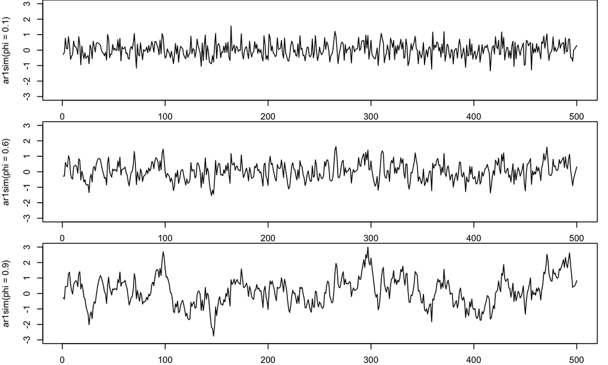

## Some features of an AR(1) process

- In an AR(1) process, a shock will have an effect for an infinite amount of time!
- In practice, this decays exponentially if \(\phi<1\).
- We can see this if we look at the **autocorrelation function**

## The autocorrelation function

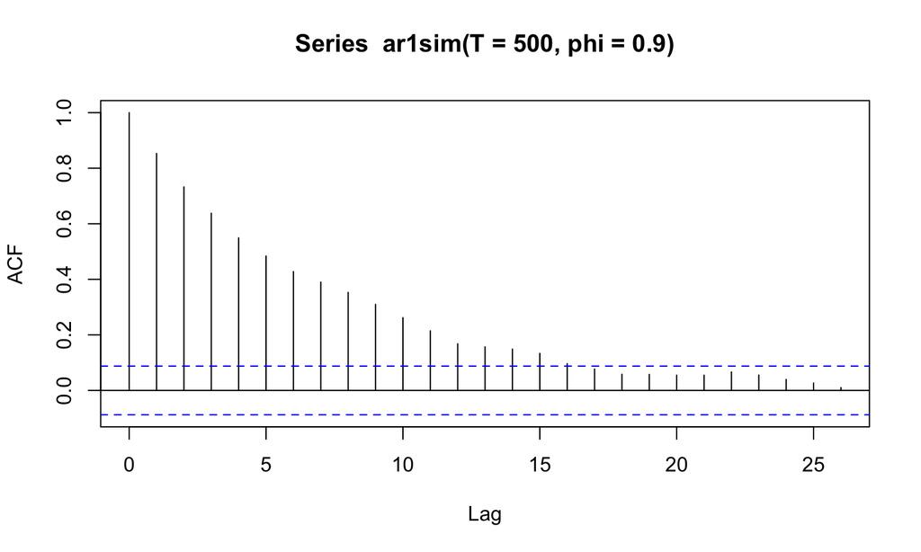

```r
acf(ar1sim(T = 500, phi = 0.9))
```

## Negative autocorrelation

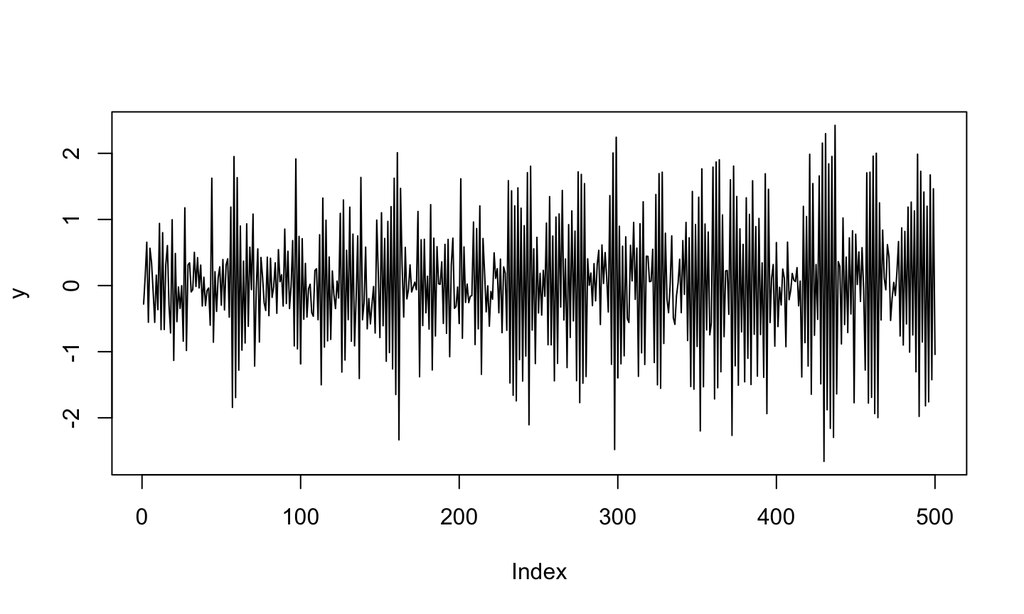

```r
y <- ar1sim(T = 500, phi = -0.9)
plot(y, type = 'l')
```

## The acf for negative autocorrelation

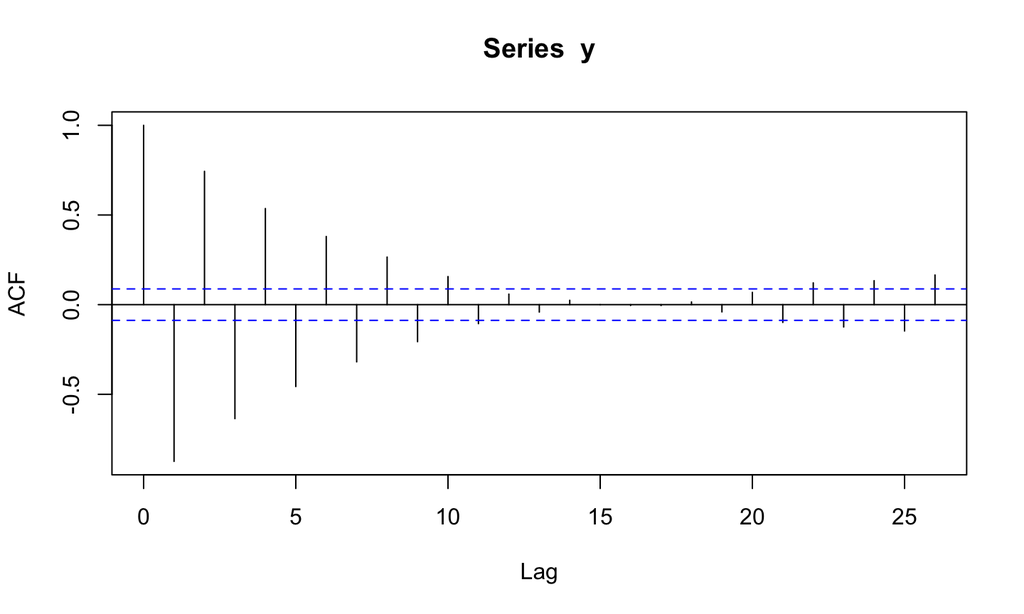

```r
acf(y)
```

## The partial autocorrelation function

The **partial** autocorrelation function controls for the autocorrlation at all other lags

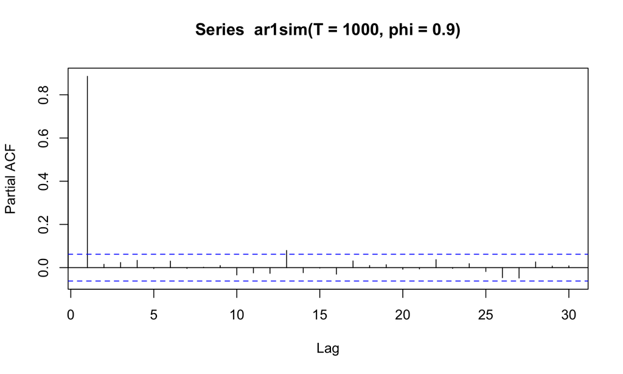

```r
pacf(ar1sim(T = 1000, phi = 0.9))
```

## Simulating from an AR(p) process

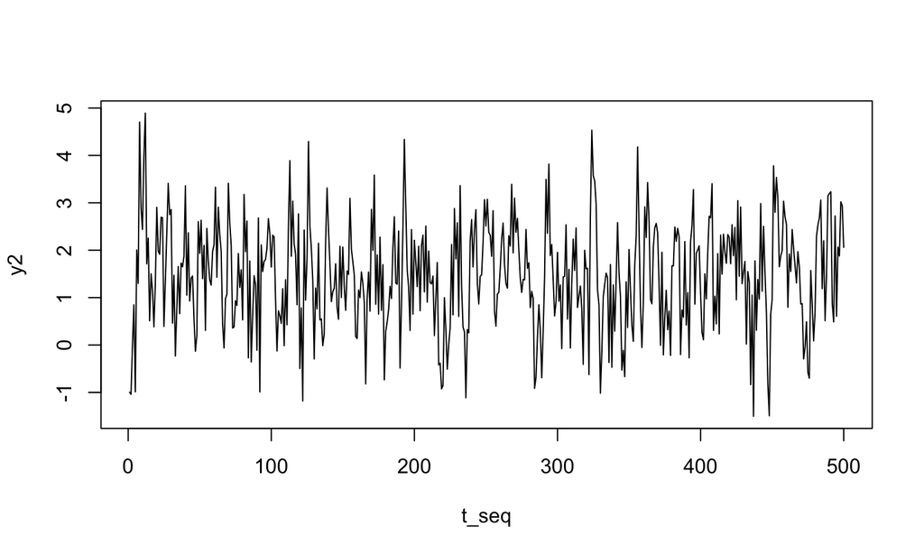

```r
# Also simulate an AR(p) process
T = 500
t_seq = 1:T
sigma = 1
alpha = 1
p = 3
phi2 = c(0.3,0.3,-0.3)
y2 = rep(NA,T)
y2[1:p] = rnorm(p,0,sigma)
for(t in (p+1):T) y2[t] = rnorm(1,alpha + sum( phi2 * y2[(t-1):(t-p)] ), sigma)
plot(t_seq,y2,type='l')
```

## PACF for an AR3 process

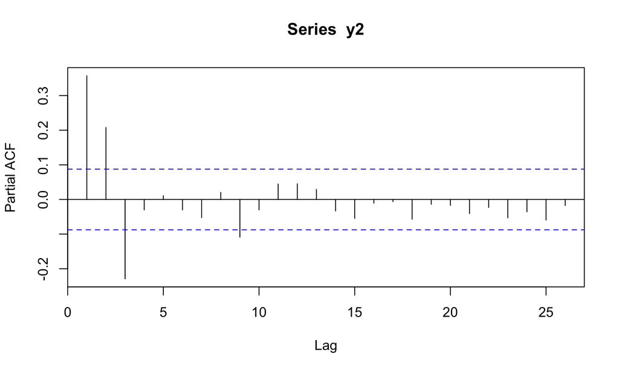

## Fitting Random Walk models in JAGS

## The temperature in Greenland in the last 100kyr

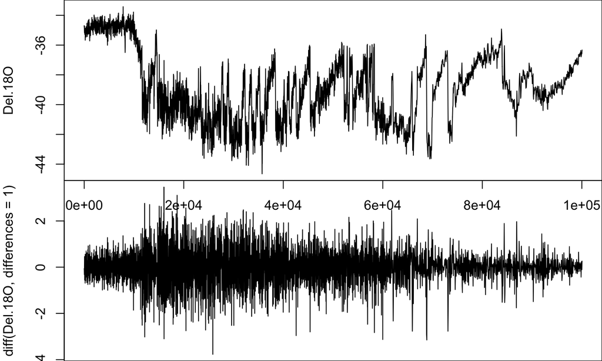

## Examining the data

```r
# Have to be careful here with differences, look:
table(diff(ice$Age))
```

```
##
##   20   40   50   60  100  120
## 3035    2  779    2    1    1
```

```r
# The random walk model we use requires evenly spaced time differences
# Just use the Holocene as most of this is 20-year
ice2 = subset(ice,Age<=10000)
table(diff(ice2$Age))
```

```
##
##  20  40  60
## 496   1   1
```

## Just keep the Holocene

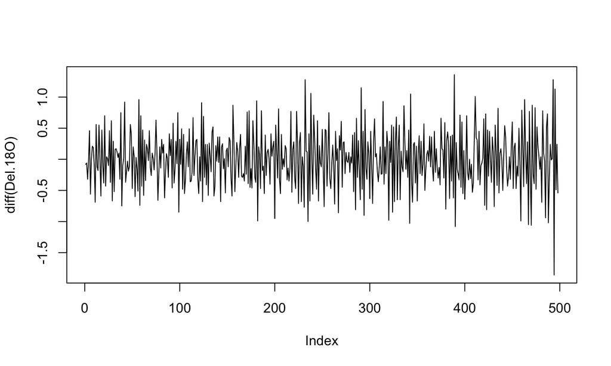

## Setting up the model

```r
# Jags code to fit the model to the simulated data
# Note: running the differencing offline here as part of the data step
model_code = '
model
{
  # Likelihood
  for (t in 1:N_T) {
    z[t] ~ dnorm(mu, tau)
  }

  # Priors
  mu ~ dnorm(0.0,0.01)
  tau <- 1/pow(sigma,2) # Turn precision into standard deviation
  sigma ~ dunif(0.0,100.0)
}
'
```

## Run the model

```r
# Choose the parameters to watch
model_parameters =  c("mu","sigma")

# Set up the data
order = 1
T = 100
real_data = with(ice2,
                 list(z = diff(Del.18O, differences=order), N_T = T-order))

# Run the model
real_data_run = jags(data = real_data,
                     parameters.to.save = model_parameters,
                     model.file=textConnection(model_code),
                     n.chains=4,
                     n.iter=1000,
                     n.burnin=200,
                     n.thin=2)
```

## Check the model

```r
print(real_data_run)
```

```
## Inference for Bugs model at "5", fit using jags,
##  4 chains, each with 1000 iterations (first 200 discarded), n.thin = 2
##  n.sims = 1600 iterations saved
##          mu.vect sd.vect    2.5%     25%     50%     75%   97.5%  Rhat
## mu        -0.002   0.041  -0.085  -0.030  -0.001   0.026   0.081 1.001
## sigma      0.408   0.029   0.358   0.388   0.406   0.426   0.471 1.002
## deviance 102.212   2.051 100.246 100.738 101.571 103.028 107.687 1.011
##          n.eff
## mu        1600
## sigma     1200
## deviance   560
##
## For each parameter, n.eff is a crude measure of effective sample size,
## and Rhat is the potential scale reduction factor (at convergence, Rhat=1).
##
## DIC info (using the rule, pD = var(deviance)/2)
## pD = 2.1 and DIC = 104.3
## DIC is an estimate of expected predictive error (lower deviance is better).
```

## Make some predictions

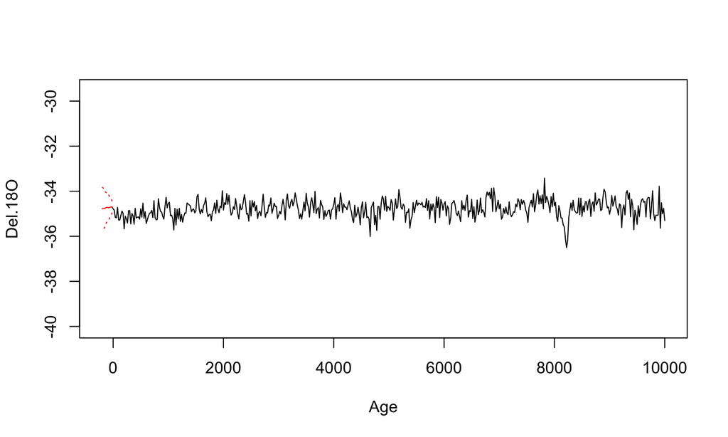

## Zoom in on the predcition

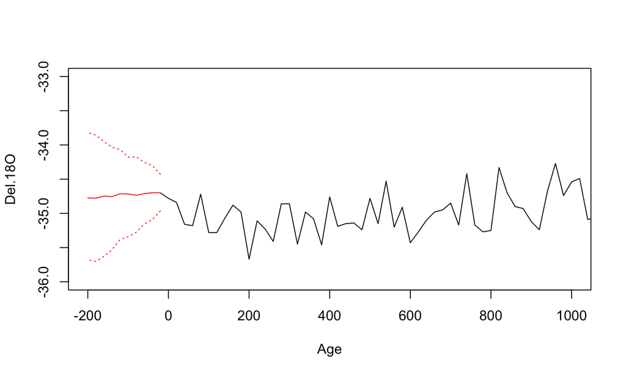

There is more detail in jags_random_walks.R

## Fitting AR models in JAGS

## The Bayesian AR model

```r
# Description of the Bayesian model fitted in this file
# Notation:
# y(t) = response variable at time t, t = 1,...,T
# alpha = overall mean parameter
# phi = autocorrelation/autoregressive (AR) parameter
# phi_j = Some of the models below have multiple AR parameters, j = 1,..P
# sigma = residual standard deviation

# Likelihood
# For AR(1)
# y[t] ~ normal(alpha + phi * y[t-1], sigma^2)
# For AR(p)
# y[t] ~ normal(alpha + phi[1] * y[t-1] + ... + phi[p] * y[y-p], sigma^2)

# Priors
# alpha ~ dnorm(0,100)
# phi ~ dunif(-1,1) # If you want the process to be stable/stationary
# phi ~ dnorm(0,100) # If you're not fussed about stability
# sigma ~ dunif(0,100)
```

## The JAGS general AR(p) model

```r
model_code = '
model
{
  # Likelihood
  for (t in (p+1):T) {
    y[t] ~ dnorm(mu[t], tau)
    mu[t] <- alpha + inprod(phi, y[(t-p):(t-1)])
  }

  # Priors
  alpha ~ dnorm(0.0,0.01)
  for (i in 1:p) {
    phi[i] ~ dnorm(0.0,0.01)
  }
  tau <- 1/pow(sigma,2) # Turn precision into standard deviation
  sigma ~ dunif(0.0,10.0)
}
'
```

```r
# Choose the parameters to watch
model_parameters =  c("alpha","phi","sigma")
```

## Let's fit the HadCRUT4 data

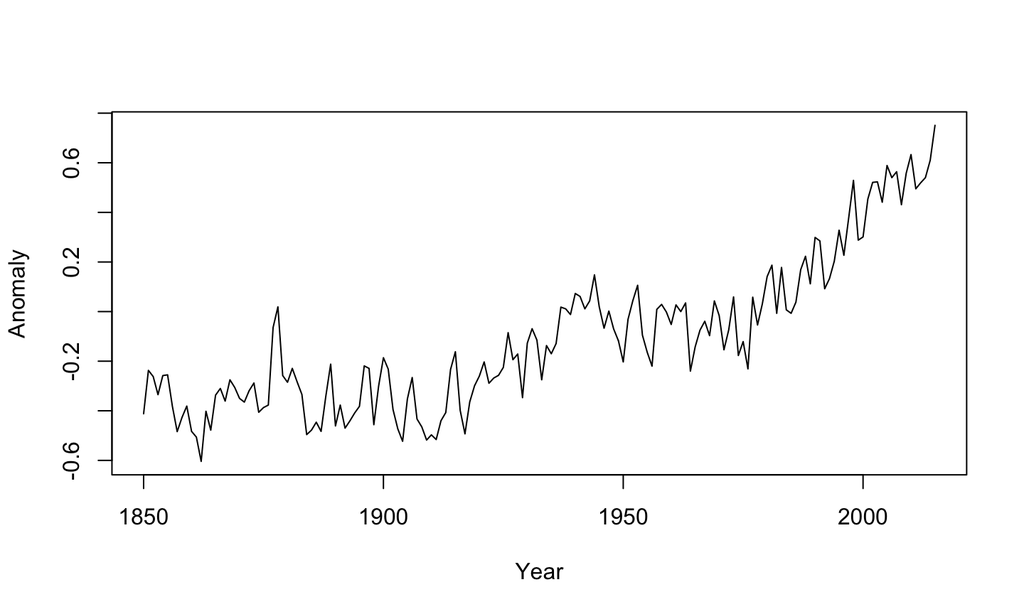

## Run the model

```r
# Set up the data
real_data = with(hadcrut,
                 list(T = nrow(hadcrut),
                      y = hadcrut$Anomaly,
                      p = 1))

# Run the model
real_data_run = jags(data = real_data,
                     parameters.to.save = model_parameters,
                     model.file=textConnection(model_code),
                     n.chains=4,
                     n.iter=1000,
                     n.burnin=200,
                     n.thin=2)
```

## Check the model fit

```r
# Plot output
print(real_data_run) # Very high degree of autocorrelation
```

```
## Inference for Bugs model at "6", fit using jags,
##  4 chains, each with 1000 iterations (first 200 discarded), n.thin = 2
##  n.sims = 1600 iterations saved
##           mu.vect sd.vect     2.5%      25%      50%      75%    97.5%
## alpha       0.001   0.010   -0.018   -0.005    0.001    0.008    0.019
## phi         0.947   0.030    0.889    0.927    0.946    0.967    1.005
## sigma       0.114   0.006    0.102    0.110    0.114    0.118    0.128
## deviance -249.730   2.453 -252.562 -251.545 -250.352 -248.574 -243.597
##           Rhat n.eff
## alpha    1.002  1600
## phi      1.002  1100
## sigma    1.002  1600
## deviance 1.006   530
##
## For each parameter, n.eff is a crude measure of effective sample size,
## and Rhat is the potential scale reduction factor (at convergence, Rhat=1).
##
## DIC info (using the rule, pD = var(deviance)/2)
## pD = 3.0 and DIC = -246.7
## DIC is an estimate of expected predictive error (lower deviance is better).
```

## Create one-step-ahead predictions

[output not shown]

## Create one-step-ahead predictions

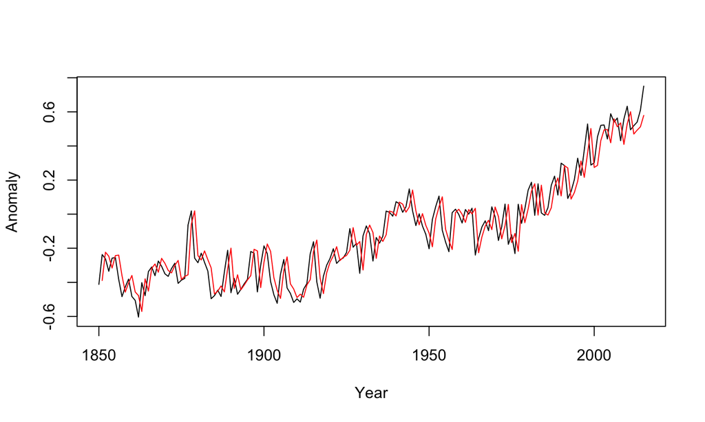

## Create some predictions off into the future

See, no global warming!

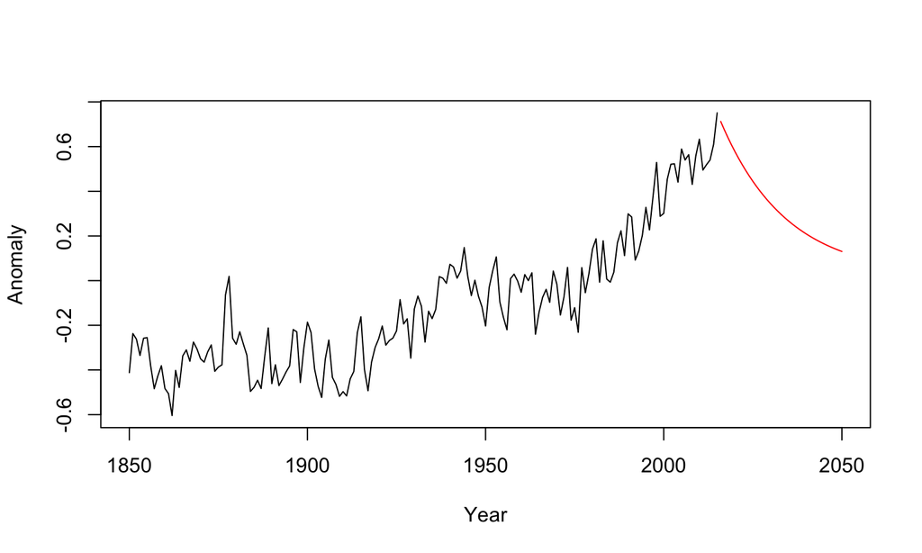